# Telco customers churn analysis

This comprehensive analysis of Telco customer churn provides an in-depth data overview, including a churn distribution, correlation analysis of key features, a performance comparison of three classifiers, and an interactive prediction tool within one data app constructed using Holoviz Panel.

### Configurations

```python
import numpy as np
import pandas as pd
import matplotlib.pyplot as plt
import seaborn as sns
import panel as pn
import matplotlib.colors
from sklearn.model_selection import train_test_split
from sklearn.metrics import confusion_matrix, ConfusionMatrixDisplay,classification_report
from sklearn.tree import DecisionTreeClassifier
from sklearn.ensemble import RandomForestClassifier
from sklearn.ensemble import AdaBoostClassifier
```

```python
#Colors
background = '#F0F0F0'
red = '#ED462F'
pink = '#F1BBB8'
green = '#4CB866'
blue = '#003D83'
black = '#333333'
grey = '#D0D9DC'
darkgrey = '#8C9496'
white = 'white'
```

```python
#Matplotlib styles
plt.rcParams['axes.facecolor'] = grey
plt.rcParams['figure.facecolor'] = background
plt.rcParams['font.family'] = 'monospace'
plt.rcParams['xtick.color'] = background
plt.rcParams['ytick.color'] = background
plt.rcParams['xtick.labelcolor'] = darkgrey
plt.rcParams['ytick.labelcolor'] = darkgrey
plt.rcParams['legend.labelcolor'] = darkgrey
plt.rcParams['grid.color'] = background
plt.rcParams['axes.spines.left'] = False
plt.rcParams['axes.spines.right'] = False
plt.rcParams['axes.spines.top'] = False
plt.rcParams['axes.spines.bottom'] = False
plt.rcParams['axes.axisbelow'] = True
plt.rcParams['axes.grid'] = True
plt.rcParams['legend.frameon'] = False
```

```python
#CSS
css = '''
.bk-root {
    font-family: monospace
}
.bk-root .bk-tabs-header.bk-above .bk-headers-wrapper {
    border-bottom: none;
    background: #D0D9DC
}
.bk-root .bk-tabs-header.bk-above .bk-tab {
    border-width: 2px 0px 0px 0px;
    border-radius: 0px;
    border-color: #D0D9DC
}
.bk-root .bk-tabs-header .bk-tab.bk-active {
    color: black;
    background-color: #F0F0F0;
}
.bk-root .bk-tabs-header .bk-headers-wrapper {
    color: black;
}
.bk-root .bk-tabs-header .bk-tab {
    padding: 15px 15px;
}
.bk-root .bk-tabs-header .bk-tab:hover {
    background-color: black;
    color: #F0F0F0
}
.bk-root .bk-input {
    border-radius: 0px;
    border: none;
    box-shadow:none;
    background:#D0D9DC
}

'''
pn.extension(raw_css=[css])
```

## 1. EDA

In this initial step, data exploration was conducted to identify important correlations, laying the groundwork for the subsequent step of predictive analysis.

### Read data

```python
df = pd.read_csv('Telco-Customer-Churn-edited.csv')
df.head()
```

|  | customerID | gender | SeniorCitizen | Partner | Dependents | tenure | PhoneService | MultipleLines | InternetService | OnlineSecurity | ... | DeviceProtection | TechSupport | StreamingTV | StreamingMovies | Contract | PaperlessBilling | PaymentMethod | MonthlyCharges | TotalCharges | Churn |
| --- | --- | --- | --- | --- | --- | --- | --- | --- | --- | --- | --- | --- | --- | --- | --- | --- | --- | --- | --- | --- | --- |
| 0 | 7590-VHVEG | Female | 0 | Yes | No | 1 | No | No phone | DSL | No | ... | No | No | No | No | Monthly | Yes | EC | 29.85 | 29.85 | No |
| 1 | 5575-GNVDE | Male | 0 | No | No | 34 | Yes | No | DSL | Yes | ... | Yes | No | No | No | 1 year | No | MC | 56.95 | 1889.50 | No |
| 2 | 3668-QPYBK | Male | 0 | No | No | 2 | Yes | No | DSL | Yes | ... | No | No | No | No | Monthly | Yes | MC | 53.85 | 108.15 | Yes |
| 3 | 7795-CFOCW | Male | 0 | No | No | 45 | No | No phone | DSL | Yes | ... | Yes | Yes | No | No | 1 year | No | BT | 42.30 | 1840.75 | No |
| 4 | 9237-HQITU | Female | 0 | No | No | 2 | Yes | No | Fiber | No | ... | No | No | No | No | Monthly | Yes | EC | 70.70 | 151.65 | Yes |

5 rows × 21 columns

```python
df.info()
```

```
<class 'pandas.core.frame.DataFrame'>
RangeIndex: 7032 entries, 0 to 7031
Data columns (total 21 columns):
 #   Column            Non-Null Count  Dtype
---  ------            --------------  -----
 0   customerID        7032 non-null   object
 1   gender            7032 non-null   object
 2   SeniorCitizen     7032 non-null   int64
 3   Partner           7032 non-null   object
 4   Dependents        7032 non-null   object
 5   tenure            7032 non-null   int64
 6   PhoneService      7032 non-null   object
 7   MultipleLines     7032 non-null   object
 8   InternetService   7032 non-null   object
 9   OnlineSecurity    7032 non-null   object
 10  OnlineBackup      7032 non-null   object
 11  DeviceProtection  7032 non-null   object
 12  TechSupport       7032 non-null   object
 13  StreamingTV       7032 non-null   object
 14  StreamingMovies   7032 non-null   object
 15  Contract          7032 non-null   object
 16  PaperlessBilling  7032 non-null   object
 17  PaymentMethod     7032 non-null   object
 18  MonthlyCharges    7032 non-null   float64
 19  TotalCharges      7032 non-null   float64
 20  Churn             7032 non-null   object
dtypes: float64(2), int64(2), object(17)
memory usage: 1.1+ MB
```

### Descriptive analysis

**1. Overall churn**

The initial step of the descriptive analysis was to explore the overall customer churn across the entire data frame.A donut chart was employed to represent this visually.

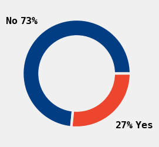

```python
#Figure
fig = plt.figure(figsize=(3,3))

#Values and labels for the pie plot
values = [len(df[df['Churn']=='No']),len(df[df['Churn']=='Yes'])]
labels = ['No  ','  Yes']

#Pie plot
plt.pie(values,labels=labels,colors=[blue,red],autopct='%1.0f%%',pctdistance=1.3,labeldistance=1.3,
               textprops={'fontsize':12,'fontweight':'bold','va':'center'},
               wedgeprops={'linewidth':3,'edgecolor':background})

#Circle patch to transform into donut chart
my_circle1 = plt.Circle((0,0), 0.7, color=background)
plt.gca().add_artist(my_circle1)

#Saving the figure locally
plt.savefig('CustomerChurn.png');
```

The chart indicated that the percentage of customers who churned during the given period was less than 30%.

**2. Features correlation**

A close exploration was conducted to determine which features contributed the most to customer churn through correlation with the 'Churn_Yes' column. A bubble chart was then employed to visually demonstrate the most correlated features.

```python
df_wd = df.drop('customerID',axis=1) #customer ID is irrelevant
df_wd = pd.get_dummies(df_wd)
df_wd.corr()['Churn_Yes'] #get correlation rating to churn
```

```
SeniorCitizen              0.150541
tenure                    -0.354049
MonthlyCharges             0.192858
TotalCharges              -0.199484
gender_Female              0.008545
gender_Male               -0.008545
Partner_No                 0.149982
Partner_Yes               -0.149982
Dependents_No              0.163128
Dependents_Yes            -0.163128
PhoneService_No           -0.011691
PhoneService_Yes           0.011691
MultipleLines_No          -0.032654
MultipleLines_No phone    -0.011691
MultipleLines_Yes          0.040033
InternetService_DSL       -0.124141
InternetService_Fiber      0.307463
InternetService_No        -0.227578
OnlineSecurity_No          0.342235
OnlineSecurity_No int     -0.227578
OnlineSecurity_Yes        -0.171270
OnlineBackup_No            0.267595
OnlineBackup_No int       -0.227578
OnlineBackup_Yes          -0.082307
DeviceProtection_No        0.252056
DeviceProtection_No int   -0.227578
DeviceProtection_Yes      -0.066193
TechSupport_No             0.336877
TechSupport_No int        -0.227578
TechSupport_Yes           -0.164716
StreamingTV_No             0.128435
StreamingTV_No int        -0.227578
StreamingTV_Yes            0.063254
StreamingMovies_No         0.130920
StreamingMovies_No int    -0.227578
StreamingMovies_Yes        0.060860
Contract_1 year           -0.178225
Contract_2 year           -0.301552
Contract_Monthly           0.404565
PaperlessBilling_No       -0.191454
PaperlessBilling_Yes       0.191454
PaymentMethod_BT          -0.118136
PaymentMethod_CC          -0.134687
PaymentMethod_EC           0.301455
PaymentMethod_MC          -0.090773
Churn_No                  -1.000000
Churn_Yes                  1.000000
Name: Churn_Yes, dtype: float64
```

```python
churn_yes = df_wd.corr()['Churn_Yes'][:-2] #removing the actual churn (last two items)
```

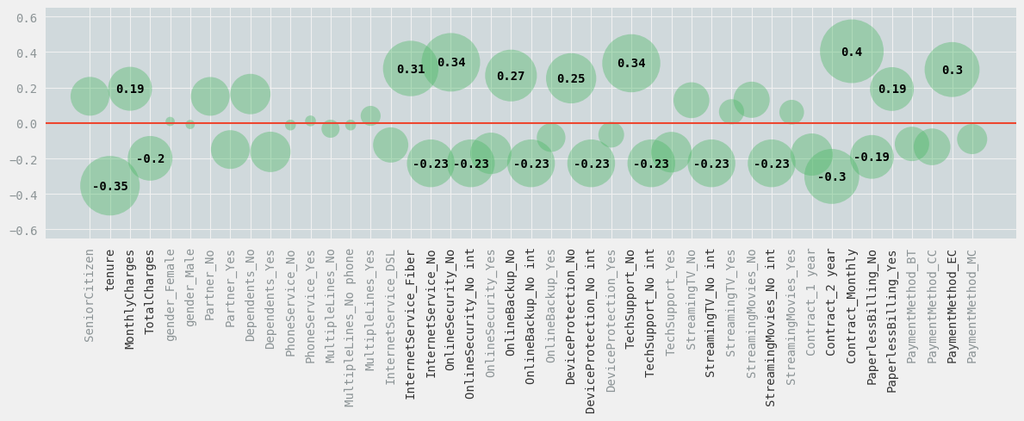

```python
#Figure
fig = plt.figure(figsize=(12,5))

#Data-dependent sizes of points
sizes = abs(churn_yes.values)*7000

#Scatterplot
plt.scatter(x=churn_yes.index,y=churn_yes.values,s=sizes,c=green,alpha=0.4,lw=0)

#Adjusting the plot
plt.ylim(-0.65,0.65)
plt.xticks(rotation=90)

#Annotations and highlighting
for x,y in zip(churn_yes.index,churn_yes.values):
    if abs(y)>0.18:
        fi = round(y,2)
        plt.text(x,y,f'{fi}',fontweight='bold',fontsize=10,ha='center',va='center')
        plt.gca().get_xticklabels()[churn_yes.index.get_loc(x)].set_color(black)

#0 line
plt.axhline(0,color=red)

#Tight layout
plt.tight_layout()

#Saving the figure locally
plt.savefig('FeaturesCorrelation.png');
```

A correlation threshold of 0.18 revealed that the following features had the most significant influence on customer churn:

- Contract type (monthly: 0.4 and two year: -0.3)
- Online security(no security: 0.34 and no internet: -0.23)
- Tech support(no support: 0.34)
- Internet service (fiber optic: 0.31)
- Payment method (electronic check: 0.3)
- Paperless billing (yes: 0.19 and no: -0.19)
- Online backup (no backup: 0.27 and no internet: -0.23)
- Device protection (no protection: 0.25 and no internet: -0.23)
- Streaming TV (no internet: -0.23)
- Streaming Movies (no internet: -0.23)
- Tenure (-0.35)
- Monthly charges (0.19)
- Total charges (-0.2)

Out of 13 features 10 of them were categorical and 3 numeric which were further explored separately.

**3. The most correlated categorical features**

Categorical features were then individually explored in relation to churn in order to visually demonstrate their impact.

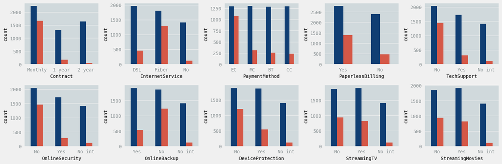

```python
#Figure
fig,axes = plt.subplots(nrows=2,ncols=5,figsize=(15,5))

#Countplots
sns.countplot(data=df,x='Contract',hue='Churn',palette=[blue,red],width=0.5,ax=axes[0,0])
sns.countplot(data=df,x='InternetService',hue='Churn',palette=[blue,red],width=0.5,ax=axes[0,1])
sns.countplot(data=df,x='PaymentMethod',hue='Churn',palette=[blue,red],width=0.5,ax=axes[0,2])
sns.countplot(data=df,x='PaperlessBilling',hue='Churn',palette=[blue,red],width=0.5,ax=axes[0,3])
sns.countplot(data=df,x='TechSupport',hue='Churn',palette=[blue,red],width=0.5,ax=axes[0,4])
sns.countplot(data=df,x='OnlineSecurity',hue='Churn',palette=[blue,red],width=0.5,ax=axes[1,0])
sns.countplot(data=df,x='OnlineBackup',hue='Churn',palette=[blue,red],width=0.5,ax=axes[1,1])
sns.countplot(data=df,x='DeviceProtection',hue='Churn',palette=[blue,red],width=0.5,ax=axes[1,2])
sns.countplot(data=df,x='StreamingTV',hue='Churn',palette=[blue,red],width=0.5,ax=axes[1,3])
sns.countplot(data=df,x='StreamingMovies',hue='Churn',palette=[blue,red],width=0.5,ax=axes[1,4])

#Removing legends to declutter
axes_list = list(axes[0])+list(axes[1])
for ax in axes_list:
    ax.legend([],[])

#Tight layout
plt.tight_layout()

#Saving figure locally
plt.savefig('CatFeats.png');
```

Analysis of the plots revealed that:

- customers with monthly contract type displayed a significantly higher churn rate compared to those with two year contracts
- surprisingly, customers whose internet was supplied via fiber optic experienced a higher churn rate
- the electronic check payment method had a signigficant negative influence on customer retention
- paperless billing, when present, had an impact on cutomer churn
- a noticeable trend was observed among the features related to technical services provided to customers with internet access (tech support, online security, online backup, device protection and streaming services). It was found that customer churn was significantly higher when those services were absent, whereas the lack of internet connection (and therefore the lack of those services) did not have a significant impact on churn.

**4. The most correlated numeric features**

The two-way approach was chosen for the visualisation of the numeric features. The distribution of churn was visualised for each feature, followed by plotting the features against each other.

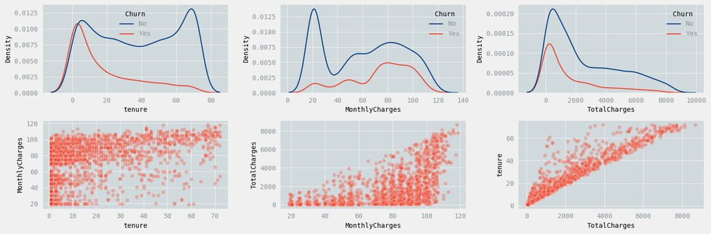

```python
#Figure
fig,axes = plt.subplots(nrows=2,ncols=3,figsize=(15,5))

#KDE plots
sns.kdeplot(data=df,x='tenure',hue='Churn',palette=[blue,red],ax=axes[0,0])
sns.kdeplot(data=df,x='MonthlyCharges',hue='Churn',palette=[blue,red],ax=axes[0,1])
sns.kdeplot(data=df,x='TotalCharges',hue='Churn',palette=[blue,red],ax=axes[0,2])

#Scatter plots
sns.scatterplot(data=df[df['Churn']=='Yes'],x='tenure',y='MonthlyCharges',
                color=red,alpha=0.3,ax=axes[1,0],legend=False)
sns.scatterplot(data=df[df['Churn']=='Yes'],x='MonthlyCharges',y='TotalCharges',
                color=red,alpha=0.3,ax=axes[1,1],legend=False)
sns.scatterplot(data=df[df['Churn']=='Yes'],x='TotalCharges',y='tenure',
                color=red,alpha=0.3,ax=axes[1,2],legend=False)

#Tight layout
plt.tight_layout()

#Saving figure locally
plt.savefig('NumFeats.png');
```

It was observed that a lower tenure (less than 10 months) had a greater impact on customer churn than a higher tenure (around 70 months), which positively affected customer retention. Monthly charges ranging from 80-100 had a bigger impact on churn, while very low monthly charges had a positive effect on customer retention. Interestingly, it was observed that lower total fees had a considerable effect on both churn and retention, whereas higher fees did not increase the churn rate as would be expected based on the tendency with the monthly charges. It can be inferred that total charges are proportional to the tenure, as evidenced by the last plot (lower right).

## 2. Predictive analysis

The next step was to construct a prediction model utilizing existing classifiers from the sklearn library.

### Compare three classifiers

In this analysis, three classifiers were evaluated: Decision Tree, Random Forest and AdaBoost. The models were fitted on the training data derived from the data frame and their performance was visualised using a confusion matrix plot.

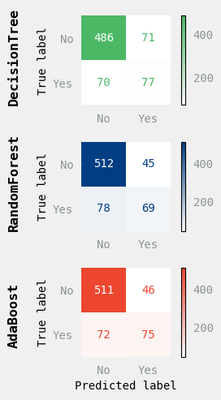

```python
#Preparing data for classification
X = df.drop(['Churn','customerID'],axis=1)
X = pd.get_dummies(X,drop_first=True)
y = df['Churn']

#Train/test split
X_train, X_test, y_train, y_test = train_test_split(X, y, test_size=0.1, random_state=101)

#Decision Tree (model fitting and prediction)
dt = DecisionTreeClassifier(max_depth=6)
dt.fit(X_train,y_train)
dt_preds = dt.predict(X_test)

#Random Forest (model fitting and prediction)
rf = RandomForestClassifier(max_depth=6)
rf.fit(X_train,y_train)
rf_preds = rf.predict(X_test)

#Ada Boost (model fitting and prediction)
ada = AdaBoostClassifier()
ada.fit(X_train,y_train)
ada_preds = ada.predict(X_test)

#Figure
fig,axes = plt.subplots(nrows=3,ncols=1,figsize=(3,5))

#Building confusion matrix for Decision Tree
cm = confusion_matrix(y_test, dt_preds, labels=dt.classes_)
disp = ConfusionMatrixDisplay(confusion_matrix=cm, display_labels=dt.classes_)
cmap = matplotlib.colors.LinearSegmentedColormap.from_list('', ['white',green])
disp.plot(cmap=cmap,ax=axes[0])
axes[0].set_title('DecisionTree',fontweight='bold',fontsize=12,rotation='vertical',x=-0.75,y=-0.05)
axes[0].xaxis.label.set_visible(False)
axes[0].grid(False)

#Building confusion matrix for Random Forest
cm = confusion_matrix(y_test, rf_preds, labels=rf.classes_)
disp = ConfusionMatrixDisplay(confusion_matrix=cm, display_labels=rf.classes_)
cmap = matplotlib.colors.LinearSegmentedColormap.from_list('', ['white',blue])
disp.plot(cmap=cmap,ax=axes[1])
axes[1].set_title('RandomForest',fontweight='bold',fontsize=12,rotation='vertical',x=-0.75,y=-0.05)
axes[1].xaxis.label.set_visible(False)
axes[1].grid(False)

#Building confusion matrix for Ada Boost
cm = confusion_matrix(y_test, ada_preds, labels=ada.classes_)
disp = ConfusionMatrixDisplay(confusion_matrix=cm, display_labels=ada.classes_)
cmap = matplotlib.colors.LinearSegmentedColormap.from_list('', ['white',red])
disp.plot(cmap=cmap,ax=axes[2])
axes[2].set_title('AdaBoost',fontweight='bold',fontsize=12,rotation='vertical',x=-0.75,y=0.05)
axes[2].grid(False)

#Tight layout
plt.tight_layout()

#Saving figure locally
plt.savefig('ConfMatrix.png',bbox_inches='tight');
```

The test revealed that the Decision Tree algorithm was most accurate in predicting churn cases, while Random Forest had the best accuracy in predicting customer retention. Therefore, it was determined that all three algorithms should be maintained in the future prediction tool to provide a balanced, objective assessment.

### Compare feature importance

Next, the feature importance of all three algorithms was measured and then visualized in a bubble plot, with the most important features highlighted.

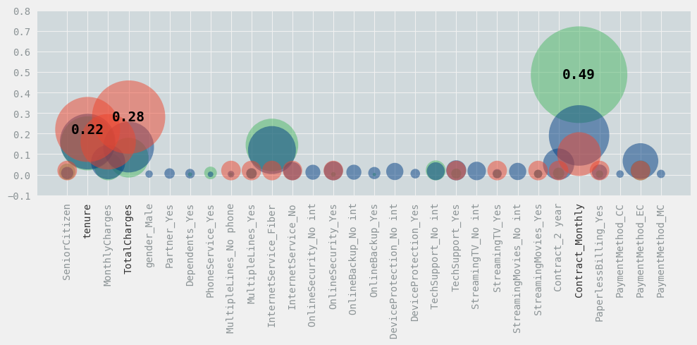

```python
#Creating a data frame with feature importances
feats = pd.DataFrame({'dt':dt.feature_importances_,'rf':rf.feature_importances_,'ada':ada.feature_importances_},
                     index=X.columns)

#Figure
fig = plt.figure(figsize=(10,5))
plt.ylim(-0.1,0.8)

#Scatter plot Decision Tree
dt_sizes = feats['dt']*20000
plt.scatter(x=feats.index,y=feats['dt'],s=dt_sizes,c=green,alpha=0.5,lw=0)
for x,y in zip(feats.index,feats['dt']):
    if y>=0.2:
        fi = round(feats.loc[x,'dt'],2)
        plt.text(x,y,f'{fi}',fontweight='bold',fontsize=14,ha='center',va='center')
        plt.gca().get_xticklabels()[feats.index.get_loc(x)].set_color(black)

#Scatter plot Random Forest
rf_sizes = feats['rf']*20000
plt.scatter(x=feats.index,y=feats['rf'],s=rf_sizes,c=blue,alpha=0.5,lw=0)
for x,y in zip(feats.index,feats['rf']):
    if y>=0.2:
        fi = round(feats.loc[x,'rf'],2)
        plt.text(x,y,f'{fi}',fontweight='bold',fontsize=14,ha='center',va='center')
        plt.gca().get_xticklabels()[feats.index.get_loc(x)].set_color(black)

#Scatter plot Ada Boost
ada_sizes = feats['ada']*20000
plt.scatter(x=feats.index,y=feats['ada'],s=ada_sizes,c=red,alpha=0.5,lw=0)
for x,y in zip(feats.index,feats['ada']):
    if y>=0.2:
        fi = round(feats.loc[x,'ada'],2)
        plt.text(x,y,f'{fi}',fontweight='bold',fontsize=14,ha='center',va='center')
        plt.gca().get_xticklabels()[feats.index.get_loc(x)].set_color(black)

#Adjusting the layout
plt.xticks(rotation=90)
plt.tight_layout()

#Saving figure locally
plt.savefig('FeatImp.png');
```

## 3. Building the dashboard

The final step was to create a dashboard to demonstrate the analysis performed with the data set as well as provide an intercative prediction tool for the customer churn. For that purpose, the Holoviz Panel library was employed, enabling the creation of input widgets that dynamically affect the results of the prediction algorithm. The prediction results were then visualized in the form of a donut chart, which allowed for the representation of the churn prediction ratio across all three classifiers.

### Input widgets

```python
gender = pn.widgets.Select(name='Gender', options=df['gender'].unique().tolist(),width=250)
SeniorCitizen = pn.widgets.Select(name='Senior Citizen', options=df['SeniorCitizen'].unique().tolist(),width=250)
Partner = pn.widgets.Select(name='Partner', options=df['Partner'].unique().tolist(),width=250)
Dependents = pn.widgets.Select(name='Dependents', options=df['Dependents'].unique().tolist(),width=250)
tenure = pn.widgets.TextInput(name='Tenure', value='25',width=250)
PhoneService = pn.widgets.Select(name='Phone Service', options=df['PhoneService'].unique().tolist(),width=250)
MultipleLines = pn.widgets.Select(name='Multiple Lines', options=df['MultipleLines'].unique().tolist(),width=250)
InternetService = pn.widgets.Select(name='Internet Service', options=df['InternetService'].unique().tolist(),width=250)
OnlineSecurity = pn.widgets.Select(name='Online Security', options=df['OnlineSecurity'].unique().tolist(),width=250)
OnlineBackup = pn.widgets.Select(name='Online Backup', options=df['OnlineBackup'].unique().tolist(),width=250)
DeviceProtection = pn.widgets.Select(name='Device Protection', options=df['DeviceProtection'].unique().tolist(),width=250)
TechSupport = pn.widgets.Select(name='Tech Support', options=df['TechSupport'].unique().tolist(),width=250)
StreamingTV = pn.widgets.Select(name='Streaming TV', options=df['StreamingTV'].unique().tolist(),width=250)
StreamingMovies = pn.widgets.Select(name='Streaming Movies', options=df['StreamingMovies'].unique().tolist(),width=250)
Contract = pn.widgets.Select(name='Contract', options=df['Contract'].unique().tolist(),width=250)
PaperlessBilling = pn.widgets.Select(name='Paperless Billing', options=df['PaperlessBilling'].unique().tolist(),width=250)
PaymentMethod = pn.widgets.Select(name='Payment Method', options=df['PaymentMethod'].unique().tolist(),width=250)
MonthlyCharges = pn.widgets.TextInput(name='Monthly Charges', value='18.25',width=250)
TotalCharges = pn.widgets.TextInput(name='Total Charges', value='18.8',width=250)
```

### Plotting function

```python
#Takes in widgets values > returns a donut chart with the prediction results from all three classifiers
def pred(gender,SeniorCitizen,Partner,Dependents,tenure,PhoneService,MultipleLines,InternetService,
         OnlineSecurity,OnlineBackup,DeviceProtection,TechSupport,StreamingTV,StreamingMovies,Contract,
         PaperlessBilling,PaymentMethod,MonthlyCharges,TotalCharges):

    #Read data
    df = pd.read_csv('Telco-Customer-Churn-edited.csv')

    #Input df from the widget values
    input_df = pd.DataFrame({'gender':gender,'SeniorCitizen':SeniorCitizen,'Partner':Partner,'Dependents':Dependents,
                            'tenure':int(tenure),'PhoneService':PhoneService,'MultipleLines':MultipleLines,
                            'InternetService':InternetService,'OnlineSecurity':OnlineSecurity,'OnlineBackup':OnlineBackup,
                            'DeviceProtection':DeviceProtection,'TechSupport':TechSupport,
                            'StreamingTV':StreamingTV,'StreamingMovies':StreamingMovies,'Contract':Contract,
                            'PaperlessBilling':PaperlessBilling,'PaymentMethod':PaymentMethod,
                            'MonthlyCharges':float(MonthlyCharges),'TotalCharges':float(TotalCharges)},index=[0])

    #Concatenated df
    df = pd.concat([df,input_df])

    #Preparing data for classification
    X = df.drop(['Churn','customerID'],axis=1)
    X = pd.get_dummies(X,drop_first=True)
    X_train = X.iloc[:-1]
    X_test = X.iloc[[-1]]
    y_train = df.iloc[:-1,-1]

    #Decision Tree fitting
    dt = DecisionTreeClassifier(max_depth=6)
    dt.fit(X_train,y_train)

    #Random Forest fitting
    rf = RandomForestClassifier(max_depth=6)
    rf.fit(X_train,y_train)

    #Ada Boost fitting
    ada = AdaBoostClassifier()
    ada.fit(X_train,y_train)

    #Prediction
    dt_pred = dt.predict(X_test)
    rf_pred = rf.predict(X_test)
    ada_pred = ada.predict(X_test)

    #Values  and labels for the donut plot
    preds = [dt_pred,rf_pred,ada_pred]
    no = []
    yes = []

    #Assigning labels
    for i in preds:
        if i == 'No':
            no.append(i)
        else:
            yes.append(i)
    values = [len(no),len(yes)]
    if values[0]==3:
        labels = ['No','']
    elif values[0]==0:
        labels = ['','Yes']
    else:
        labels = ['No','Yes']

    #Figure
    fig = plt.figure(figsize=(2.7,2.7))

    #Pie plot
    plt.pie(values,labels=labels,colors=[blue,red],labeldistance=1.2,
            textprops={'fontsize':12,'fontweight':'bold','va':'center'},
            wedgeprops={'linewidth':3,'edgecolor':background})

    #Circle patch
    my_circle1 = plt.Circle((0,0), 0.7, color=background)
    plt.gca().add_artist(my_circle1)

    #Closing the figure
    plt.close(fig)

    return fig
```

### Bound layout

```python
layout = pn.interact(pred,gender=gender,SeniorCitizen=SeniorCitizen,Partner=Partner,Dependents=Dependents,
                     tenure=tenure,PhoneService=PhoneService,MultipleLines=MultipleLines,
                     InternetService=InternetService,OnlineSecurity=OnlineSecurity,OnlineBackup=OnlineBackup,
                     DeviceProtection=DeviceProtection,TechSupport=TechSupport,StreamingTV=StreamingTV,
                     StreamingMovies=StreamingMovies,Contract=Contract,PaperlessBilling=PaperlessBilling,
                     PaymentMethod=PaymentMethod,MonthlyCharges=MonthlyCharges,TotalCharges=TotalCharges)
```

```python
pr_layout = pn.Row(pn.Column(layout[0][0],layout[0][1],layout[0][2],layout[0][3],layout[0][4],layout[0][5],
                             layout[0][6],layout[0][7],layout[0][8],layout[0][9]),
                   pn.Column(layout[0][10],layout[0][11],layout[0][12],layout[0][13],layout[0][14],
                             layout[0][15],layout[0][16],layout[0][17],layout[0][18]),
                   layout[1],background=background)
pr_layout
```

[interactive chart not shown]

### Panel app

```python
tab1 = pn.Row(pn.Column(pn.pane.Markdown('###// Customer churn'),
                        pn.pane.PNG('CustomerChurn.png',margin=0,width=270)),
              pn.Column(pn.pane.Markdown('###// Features correlation'),
                        pn.pane.PNG('FeaturesCorrelation.png',margin=0,width=1080)),
              margin=20)
tab2 = pn.Column(pn.pane.Markdown('###// The most correlated categorical features'),
                 pn.pane.PNG('CatFeats.png',margin=0,width=1350),
                 margin=20)
tab3 = pn.Column(pn.pane.Markdown('###// The most correlated numeric features'),
                 pn.pane.PNG('NumFeats.png',margin=0,width=1350),
                 margin=20)

tab4 = pn.Row(pn.Column(pn.pane.Markdown('###// Confusion matrix'),
                        pn.pane.PNG('ConfMatrix.png',margin=0,width=270)),
              pn.Column(pn.pane.Markdown('###// Feature importance'),
                        pn.pane.PNG('FeatImp.png',margin=0,width=1080)),
              margin=20)
widgets = pn.Row(pn.Column(layout[0][0],layout[0][1],layout[0][2],layout[0][3],layout[0][4]),
                 pn.Column(layout[0][5],layout[0][6],layout[0][7],layout[0][8],layout[0][9]),
                 pn.Column(layout[0][10],layout[0][11],layout[0][12],layout[0][13],layout[0][14]),
                 pn.Column(layout[0][15],layout[0][16],layout[0][17],layout[0][18]))

tab5 = pn.Row(pn.Column(pn.pane.Markdown('###// Input features'),widgets),
              pn.Column(pn.pane.Markdown('###// Churn predictions'),layout[1]),
              margin=20)

tabs = pn.Tabs(('Descriptive analysis: overview', tab1),
               ('Descriptive analysis: categorical features',tab2),
               ('Descriptive analysis: numeric features', tab3),
               ('Predictive analysis: overview', tab4),
               ('Predictions', tab5),
               background=background)
panel = pn.Column(pn.pane.Markdown('##_Customer churn analysis: Telco customer database',margin=(0,15)),
                  tabs,background=grey)
panel.servable()
```

[interactive chart not shown]